# Validation of the fast alpha functions against psych::alpha()

Author

Ian Hussey

Published

August 2, 2026

# Purpose

`simulation_1_bias.qmd` needs, for every replication, the sample Cronbach’s alpha of the full item pool and the sample alpha of the pool with each item removed in turn. The obvious implementation calls `psych::alpha()` once per item, which builds a large object of item statistics (item-total correlations, item means and SDs, alpha standard errors) that the simulation never uses, and does so $k$ times per replication.

`simulation_functions.R` instead computes both quantities directly from a single covariance matrix:

$$\hat\alpha(S) \;=\; \frac{m}{m-1}\left(1 - \frac{\operatorname{tr}(\mathbf{S})}{\mathbf{1}^\top \mathbf{S}\mathbf{1}}\right), \qquad m = |S|$$

and obtains all $k$ leave-one-out alphas from that same matrix using

$$\operatorname{tr}(\mathbf{S}_{-j}) = \operatorname{tr}(\mathbf{S}) - S_{jj}, \qquad \mathbf{1}^\top \mathbf{S}_{-j}\mathbf{1} = \mathbf{1}^\top \mathbf{S}\mathbf{1} - 2\!\sum_i S_{ij} + S_{jj}$$

This file checks that those functions return the same numbers as `psych::alpha()` before the simulation is allowed to rely on them. It also checks the two closed-form population targets (`population_alpha_from_loadings()`, `population_omega_from_loadings()`) against values computed independently from the model-implied population covariance matrix.

Both this file and the simulation `source()` the same `simulation_functions.R`, so the functions validated here are the same objects the simulation runs — there are no second copies to drift out of sync.

# Dependencies

```r
library(psych)
library(furrr)
library(readr)
library(dplyr)
library(tidyr)
library(purrr)
library(tibble)
library(ggplot2)
library(scales)
library(knitr)
library(kableExtra)

# the functions under validation, and the DGP used to generate validation cases
source("simulation_functions.R")

# --- How many workers does THIS session/allocation actually have? -----------
# parallelly::availableCores() honours the SLURM allocation, cgroup CPU quotas,
# and affinity masks, so it returns the cores granted to THIS session -- not the
# ~196 physical cores parallel::detectCores() would report. Set the override to
# pin a count manually; leave NULL to auto-detect.
n_workers_override <- NULL
detected_cores <- unname(parallelly::availableCores())
n_workers <- if (is.null(n_workers_override)) detected_cores else as.integer(n_workers_override)
n_workers <- max(1L, as.integer(n_workers))
message(sprintf("Parallel plan: %d workers (parallelly detected %d).", n_workers, detected_cores))

# RStudio Server is not fork-safe, so use multisession (separate R processes), not multicore.
# `furrr_options(seed = TRUE)` (used in every future_* call below) advances an L'Ecuyer-CMRG
# stream per task rather than re-seeding per worker. That matters more here than usual: it
# makes the results independent of worker count, so the validation run on the cluster and a
# re-run on a laptop with a different core count produce identical numbers.
plan(multisession, workers = n_workers)
```

# Caching and the HPC workflow

Every expensive computation in this file is cached to a `.rds` under `results/`, following the same convention as `simulation_1_bias.qmd`. The intended workflow is:

1. Run this file on the HPC (render it, or `source()` the purled script) — the `.rds` files are written to `results/`.
2. Download `results/` to the local machine.
3. Re-render locally. Every cached computation is read from disk, so the tables, figures and pass/fail checks are reproduced without re-running anything.

Nothing is recomputed if its `.rds` already exists, so a local re-render costs seconds regardless of how long the original run took.

**Cache keys.** A cached validation carries a specific hazard that a cached simulation does not: if `simulation_functions.R` were edited after the cache was written, this file would happily re-render and report that the *old* functions passed, which is exactly the failure mode a validation is supposed to prevent. Each cache filename therefore embeds a hash of `simulation_functions.R` alongside the parameters that determine the result. Editing the functions changes the hash, so the old cache no longer matches and the validation re-runs rather than silently vouching for code that no longer exists. Deleting a `.rds` also forces recomputation.

```r
# Hash of the file under validation. tools::md5sum() is base R, so this adds no dependency.
# The same source file (tracked in git) gives the same hash on the cluster and locally, so a
# downloaded .rds matches; an edited simulation_functions.R gives a new hash and invalidates
# every cache below.
functions_hash <- unname(substr(tools::md5sum("simulation_functions.R"), 1, 8))

# Guard against a cache file holding the wrong object. This is not hypothetical: the cached
# path is easy to write the wrong thing to by hand, and because this is a *validation* file,
# a wrong-shaped cache would either crash the summary chunk with an opaque error or -- worse
# -- let checks appear to pass on columns that do not exist. Fail immediately, and say why.
check_cached_object <- function(object, path, required_columns) {

  if (is.null(required_columns)) return(invisible(TRUE))

  missing_columns <- setdiff(required_columns, names(object))

  if (length(missing_columns) > 0) {
    stop("The object at '", path, "' is not what this cache slot expects.\n",
         "  missing columns: ", paste(missing_columns, collapse = ", "), "\n",
         "  columns present: ", paste(names(object), collapse = ", "), "\n",
         "  This usually means a different object was written to that path. ",
         "Delete the file and re-run.",
         call. = FALSE)
  }

  invisible(TRUE)
}

# Run `computation` and cache it to `path`, or read it back if that file already exists.
# `computation` is a lazily-evaluated promise, so on the cached path it is never evaluated
# and no work is done. Provenance (where and when it was computed) is attached as an
# attribute so the rendered report can state which machine produced the numbers -- which
# matters here because the timings below are hardware-dependent.
#
# Every path in and out of this function is announced and verified. A cache write that
# silently does not happen costs a whole cluster run, and a relative `path` resolves against
# whatever the working directory happens to be -- which differs between rendering the
# document (working directory = document directory) and running its chunks interactively in
# RStudio (working directory = project root). The messages below name the absolute path
# actually used, so a file landing somewhere unexpected is visible rather than mysterious.
cache_rds <- function(path, computation, required_columns = NULL) {

  if (file.exists(path)) {
    result <- read_rds(path)
    check_cached_object(result, path, required_columns)
    message("cache_rds: loaded ", normalizePath(path))
    return(result)
  }

  message("cache_rds: no cache at '", path, "' -- computing. Working directory: ", getwd())

  cache_directory <- dirname(path)
  dir.create(cache_directory, showWarnings = FALSE, recursive = TRUE)

  if (!dir.exists(cache_directory)) {
    stop("cache_rds: could not create the results directory '", cache_directory,
         "' from working directory ", getwd(), call. = FALSE)
  }

  result <- computation

  # check before writing, so a mistake is caught at the source rather than on the next render
  check_cached_object(result, path, required_columns)

  attr(result, "provenance") <-
    list(computed_on = unname(Sys.info()[["nodename"]]),
         platform    = R.version$platform,
         computed_at = format(Sys.time(), "%Y-%m-%d %H:%M:%S %Z"))

  write_rds(x = result, file = path, compress = "gz")

  # verify the write actually landed rather than assuming it did
  if (!file.exists(path)) {
    stop("cache_rds: write_rds() did not produce a file at '", path,
         "' (working directory: ", getwd(), "). The computed result would be lost.",
         call. = FALSE)
  }

  message("cache_rds: wrote ", normalizePath(path),
          sprintf(" (%.1f KB)", file.size(path) / 1024))

  return(result)
}

# extract the provenance attribute for reporting; NA if the object predates this mechanism
cache_provenance <- function(object, path) {
  provenance <- attr(object, "provenance")
  tibble(file        = basename(path),
         computed_on = provenance$computed_on %||% NA_character_,
         platform    = provenance$platform    %||% NA_character_,
         computed_at = provenance$computed_at %||% NA_character_)
}

functions_hash
```

```
[1] "f2f42899"
```

# Validation cases

```r
n_cases_per_condition <- 40

# the grid itself is deterministic; the seed is set inside the cached computation below,
# next to the random draws it actually governs
validation_cases <- expand_grid(
  k_indicators = c(5, 10, 20),
  n_participants = c(20, 50, 100),
  case = seq_len(n_cases_per_condition)
)

# Shuffle so expensive cases are spread across workers (load balancing). Cost is steeply
# graded here -- a case calls psych::alpha() k + 1 times on n rows, so the largest
# (k, n) cell is orders of magnitude more work than the smallest -- and furrr splits the
# input into one CONTIGUOUS chunk per worker, while expand_grid() emits rows sorted by k
# then n. Unshuffled, a single worker receives every expensive case and the whole run waits
# on it. The shuffle seed is fixed, so the run stays reproducible; it does change which
# L'Ecuyer stream each case draws (furrr assigns streams by position), so the cases sampled
# differ from an unshuffled run -- reproducibly, but not identically.
set.seed(101)
validation_cases <- validation_cases[sample(nrow(validation_cases)), ]

nrow(validation_cases)
```

```
[1] 360
```

# Validation

For each case, both implementations are run on the identical dataset and their outputs compared.

```r
validate_one_case <- function(k_indicators, n_participants) {

  lambda <- draw_lambda(k_indicators = k_indicators)
  data   <- generate_data(lambda = lambda, n_participants = n_participants)

  covariance_matrix <- cov(data)

  # --- full-pool alpha ---
  alpha_custom <- alpha_from_cov(covariance_matrix)
  alpha_psych  <- psych::alpha(data, warnings = FALSE, discrete = FALSE)$total$raw_alpha

  # --- alpha with each item removed in turn ---
  alphas_if_removed_custom <- alphas_if_each_item_removed_from_cov(covariance_matrix)
  alphas_if_removed_psych  <- sapply(seq_len(ncol(data)), function(item) {
    psych::alpha(data[, -item], warnings = FALSE, discrete = FALSE)$total$raw_alpha
  })

  # --- population targets, checked against the model-implied population covariance ---
  # Sigma = lambda lambda' + diag(1 - lambda^2), i.e. exactly the covariance structure
  # generate_data() draws from. Applying the same alpha formula to Sigma is an independent
  # route to the population alpha; omega is the common-factor share of sum-score variance,
  # (sum lambda)^2 / (1' Sigma 1).
  sigma <- tcrossprod(lambda) + diag(1 - lambda^2, nrow = length(lambda))
  alpha_pop_custom <- population_alpha_from_loadings(lambda)
  alpha_pop_sigma  <- alpha_from_cov(sigma)
  omega_pop_custom <- population_omega_from_loadings(lambda)
  omega_pop_sigma  <- sum(lambda)^2 / sum(sigma)

  tibble(k_indicators   = k_indicators,
         n_participants = n_participants,
         any_negative_loading = any(lambda < 0),
         # full-pool sample alpha
         max_abs_diff_alpha_full = abs(alpha_custom - alpha_psych),
         # leave-one-out sample alphas
         max_abs_diff_alphas_if_removed = max(abs(alphas_if_removed_custom -
                                                    alphas_if_removed_psych)),
         # does each implementation nominate the same candidate item J*?
         candidate_item_agrees = which.max(alphas_if_removed_custom) ==
                                   which.max(alphas_if_removed_psych),
         # population targets
         max_abs_diff_alpha_pop = abs(alpha_pop_custom - alpha_pop_sigma),
         max_abs_diff_omega_pop = abs(omega_pop_custom - omega_pop_sigma),
         # structural inequality that the estimands rely on: alpha_pop <= omega
         alpha_pop_leq_omega = alpha_pop_custom <= omega_pop_custom + 1e-12)
}

# NB "results", not "cases": this slot holds the per-case comparison RESULTS, not the
# validation_cases grid that was fed in. The previous name invited writing the grid here.
validation_path <- paste0("results/validation_results_ncases", n_cases_per_condition,
                          "_fns", functions_hash, ".rds")

# the slow step: psych::alpha() is called k + 1 times per case
validation <- cache_rds(validation_path,
                        required_columns = c("k_indicators", "n_participants",
                                             "any_negative_loading",
                                             "max_abs_diff_alpha_full",
                                             "max_abs_diff_alphas_if_removed",
                                             "candidate_item_agrees",
                                             "max_abs_diff_alpha_pop",
                                             "max_abs_diff_omega_pop",
                                             "alpha_pop_leq_omega"),
                        computation = {

  set.seed(42)

  validation_cases |>
    select(k_indicators, n_participants) |>
    future_pmap(.f = validate_one_case,
                .progress = TRUE,
                .options = furrr_options(seed = TRUE)) |>
    bind_rows() |>
    # undo the load-balancing shuffle so the cached object is stored in a readable order.
    # Purely cosmetic: every summary below groups by condition, so order is irrelevant.
    arrange(k_indicators, n_participants)
})
```

```
cache_rds: loaded /Users/Ian-Hussey/git/replicability-of-item-dropping/code/analysis/results/validation_results_ncases40_fnsf2f42899.rds
```

## Overall result

```r
tolerance <- 1e-10

validation_summary <-
  tibble(check = c("Full-pool sample alpha vs. psych::alpha()",
                   "Leave-one-out sample alphas vs. psych::alpha()",
                   "Candidate item J* agrees",
                   "Population alpha vs. model-implied covariance matrix",
                   "Population omega vs. model-implied covariance matrix",
                   "Population alpha <= population omega"),
         max_abs_difference = c(max(validation$max_abs_diff_alpha_full),
                                max(validation$max_abs_diff_alphas_if_removed),
                                NA_real_,
                                max(validation$max_abs_diff_alpha_pop),
                                max(validation$max_abs_diff_omega_pop),
                                NA_real_),
         n_disagreements = c(sum(validation$max_abs_diff_alpha_full > tolerance),
                             sum(validation$max_abs_diff_alphas_if_removed > tolerance),
                             sum(!validation$candidate_item_agrees),
                             sum(validation$max_abs_diff_alpha_pop > tolerance),
                             sum(validation$max_abs_diff_omega_pop > tolerance),
                             sum(!validation$alpha_pop_leq_omega))) |>
  mutate(passed = n_disagreements == 0)

validation_summary |>
  kable(caption = paste0("Validation across ", nrow(validation),
                         " cases drawn from the simulation's DGP and design grid. ",
                         "Tolerance for numeric equality: ", tolerance, ".")) |>
  kable_classic(full_width = TRUE)
```

Validation across 360 cases drawn from the simulation's DGP and design grid. Tolerance for numeric equality: 0.0000000001.

| check | max_abs_difference | n_disagreements | passed |
| --- | --- | --- | --- |
| Full-pool sample alpha vs. psych::alpha() | 0 | 0 | TRUE |
| Leave-one-out sample alphas vs. psych::alpha() | 0 | 0 | TRUE |
| Candidate item J* agrees | NA | 0 | TRUE |
| Population alpha vs. model-implied covariance matrix | 0 | 0 | TRUE |
| Population omega vs. model-implied covariance matrix | 0 | 0 | TRUE |
| Population alpha <= population omega | NA | 0 | TRUE |

```r
all_checks_passed <- all(validation_summary$passed)
all_checks_passed
```

```
[1] TRUE
```

```r
if (!all_checks_passed) {
  stop("Validation failed: the fast alpha functions do not agree with psych::alpha(). ",
       "Do not use them in the simulation until this is resolved.")
}
```

## By condition

```r
validation |>
  group_by(k_indicators, n_participants) |>
  summarize(cases = n(),
            cases_with_a_negative_loading = sum(any_negative_loading),
            max_abs_diff_alpha_full = max(max_abs_diff_alpha_full),
            max_abs_diff_alphas_if_removed = max(max_abs_diff_alphas_if_removed),
            candidate_item_disagreements = sum(!candidate_item_agrees),
            .groups = "drop") |>
  kable(caption = "Maximum absolute discrepancy between the fast functions and psych::alpha(), by condition.") |>
  kable_classic(full_width = TRUE)
```

Maximum absolute discrepancy between the fast functions and psych::alpha(), by condition.

| k_indicators | n_participants | cases | cases_with_a_negative_loading | max_abs_diff_alpha_full | max_abs_diff_alphas_if_removed | candidate_item_disagreements |
| --- | --- | --- | --- | --- | --- | --- |
| 5 | 20 | 40 | 4 | 0 | 0 | 0 |
| 5 | 50 | 40 | 5 | 0 | 0 | 0 |
| 5 | 100 | 40 | 3 | 0 | 0 | 0 |
| 10 | 20 | 40 | 12 | 0 | 0 | 0 |
| 10 | 50 | 40 | 3 | 0 | 0 | 0 |
| 10 | 100 | 40 | 5 | 0 | 0 | 0 |
| 20 | 20 | 40 | 11 | 0 | 0 | 0 |
| 20 | 50 | 40 | 12 | 0 | 0 | 0 |
| 20 | 100 | 40 | 14 | 0 | 0 | 0 |

## Cases containing a negatively-loading item

The subset most likely to expose a keying difference between the two implementations.

```r
validation |>
  group_by(any_negative_loading) |>
  summarize(cases = n(),
            max_abs_diff_alpha_full = max(max_abs_diff_alpha_full),
            max_abs_diff_alphas_if_removed = max(max_abs_diff_alphas_if_removed),
            candidate_item_disagreements = sum(!candidate_item_agrees),
            .groups = "drop") |>
  kable(caption = "Discrepancies split by whether the item pool contained at least one negatively-loading item.") |>
  kable_classic(full_width = TRUE)
```

Discrepancies split by whether the item pool contained at least one negatively-loading item.

| any_negative_loading | cases | max_abs_diff_alpha_full | max_abs_diff_alphas_if_removed | candidate_item_disagreements |
| --- | --- | --- | --- | --- |
| FALSE | 291 | 0 | 0 | 0 |
| TRUE | 69 | 0 | 0 | 0 |

## Distribution of discrepancies

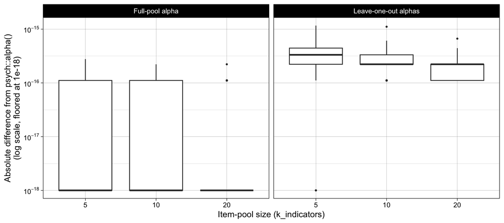

```r
validation |>
  select(k_indicators,
         `Full-pool alpha` = max_abs_diff_alpha_full,
         `Leave-one-out alphas` = max_abs_diff_alphas_if_removed) |>
  pivot_longer(cols = -k_indicators, names_to = "quantity", values_to = "abs_difference") |>
  ggplot(aes(x = as.factor(k_indicators), y = pmax(abs_difference, 1e-18))) +
  geom_boxplot(outlier.size = 0.6) +
  facet_wrap(~ quantity) +
  scale_y_log10(name = "Absolute difference from psych::alpha()\n(log scale, floored at 1e-18)",
                labels = label_log()) +
  scale_x_discrete(name = "Item-pool size (k_indicators)") +
  theme_linedraw()
```

# Does the generated data actually have the intended population structure?

The checks above establish that the sample-alpha functions agree with `psych::alpha()`, and that the closed-form population targets agree with the model-implied covariance matrix $\boldsymbol\Sigma = \boldsymbol\lambda\boldsymbol\lambda^\top + \operatorname{diag}(1 - \lambda_i^2)$. Neither establishes the link that actually matters for the simulation’s bias estimands: that `generate_data()` draws from **that** $\boldsymbol\Sigma$ and not some other one.

This is not a hypothetical concern. Given `lavaan` syntax that specifies loadings only, `lavaan::simulateData()` leaves the residual variances free and defaults them to 1, producing items with variance $\lambda_i^2 + 1$ rather than unit variance — so the population targets would describe a different population than the one sampled from, and every bias estimand would be offset by a constant that looks like (but is not) finite-sample bias. `build_cfa_model()` therefore states $\psi_i = 1 - \lambda_i^2$ explicitly; this section verifies that it worked.

Each check draws one item pool per pool size, generates a very large sample from it, and compares the realised covariance structure and sample alpha against the intended population values.

```r
n_participants_large <- 100000

check_dgp_recovery <- function(k_indicators) {

  lambda <- draw_lambda(k_indicators = k_indicators)
  data   <- generate_data(lambda = lambda, n_participants = n_participants_large)

  covariance_matrix <- cov(data)
  intended_sigma <- tcrossprod(lambda) + diag(1 - lambda^2, nrow = k_indicators)

  tibble(k_indicators = k_indicators,
         mean_item_variance = mean(diag(covariance_matrix)),
         max_abs_diff_covariance = max(abs(covariance_matrix - intended_sigma)),
         sample_alpha_large_n = alpha_from_cov(covariance_matrix),
         population_alpha = population_alpha_from_loadings(lambda),
         difference = sample_alpha_large_n - population_alpha)
}

dgp_recovery_path <- paste0("results/validation_dgp_recovery_n", n_participants_large,
                            "_fns", functions_hash, ".rds")

dgp_recovery <- cache_rds(dgp_recovery_path,
                          required_columns = c("k_indicators", "mean_item_variance",
                                               "max_abs_diff_covariance",
                                               "sample_alpha_large_n", "population_alpha",
                                               "difference"),
                          computation = {

  set.seed(2024)

  # the simulation's own item-pool sizes, so recovery is checked at exactly the pool sizes
  # the population targets will be evaluated at. These were {5, 9, 13, 21, 39} before the
  # design rounded them; note that the cache key is (n_participants_large, functions hash)
  # and does NOT include this vector, so changing it requires deleting the cached .rds --
  # otherwise the old pool sizes would be silently re-reported.
  future_map(.x = c(5, 10, 15, 20, 40),
             .f = check_dgp_recovery,
             .options = furrr_options(seed = TRUE)) |>
    bind_rows()
})
```

```
cache_rds: no cache at 'results/validation_dgp_recovery_n100000_fnsf2f42899.rds' -- computing. Working directory: /Users/Ian-Hussey/git/replicability-of-item-dropping/code/analysis
```

```
cache_rds: wrote /Users/Ian-Hussey/git/replicability-of-item-dropping/code/analysis/results/validation_dgp_recovery_n100000_fnsf2f42899.rds (0.6 KB)
```

```r
dgp_recovery |>
  mutate(across(where(is.numeric), \(x) signif(x, 4))) |>
  kable(caption = paste0("Recovery of the intended population structure at N = ",
                         format(n_participants_large, big.mark = ","),
                         ". Mean item variance should be 1, and the large-N sample alpha ",
                         "should equal the closed-form population alpha up to Monte Carlo noise.")) |>
  kable_classic(full_width = TRUE)
```

Recovery of the intended population structure at N = 100,000. Mean item variance should be 1, and the large-N sample alpha should equal the closed-form population alpha up to Monte Carlo noise.

| k_indicators | mean_item_variance | max_abs_diff_covariance | sample_alpha_large_n | population_alpha | difference |
| --- | --- | --- | --- | --- | --- |
| 5 | 1.0020 | 0.008057 | 0.6068 | 0.6061 | 0.0007253 |
| 10 | 0.9999 | 0.009693 | 0.7947 | 0.7955 | -0.0008886 |
| 15 | 0.9985 | 0.010090 | 0.7894 | 0.7891 | 0.0003444 |
| 20 | 1.0010 | 0.011060 | 0.9115 | 0.9112 | 0.0002680 |
| 40 | 0.9997 | 0.011320 | 0.9405 | 0.9406 | -0.0001438 |

```r
# Unlike the checks above, this one compares a sampled quantity against a population value,
# so the tolerance is Monte Carlo noise rather than machine precision, and must scale with
# n_participants_large -- a fixed tolerance would fail spuriously if that N were lowered.
# 10 / sqrt(N) is ~0.032 at N = 100,000, comfortably above the ~0.001 discrepancies actually
# observed but far below the ~0.08 offset that the psi = 1 misspecification produced.
dgp_tolerance <- 10 / sqrt(n_participants_large)

dgp_recovery_passed <-
  all(abs(dgp_recovery$mean_item_variance - 1) < dgp_tolerance) &
  all(abs(dgp_recovery$difference) < dgp_tolerance)

if (!dgp_recovery_passed) {
  stop("The generated data does not have the intended population covariance structure. ",
       "The population targets would not describe the sampled population, so every bias ",
       "estimand in the simulation would be offset. Do not run the simulation until this ",
       "is resolved.")
}

dgp_recovery_passed
```

```
[1] TRUE
```

# Timing

```r
# timing_path <- paste0("results/validation_timing_fns", functions_hash, ".rds")
#
# timing <- cache_rds(timing_path,
#                     required_columns = c("implementation", "seconds_per_dataset"),
#                     computation = {
#
#   set.seed(1)
#   timing_lambda <- draw_lambda(k_indicators = 39)
#   timing_data   <- generate_data(lambda = timing_lambda, n_participants = 1000)
#
#   timing_psych <- system.time({
#     for (i in 1:5) {
#       sapply(seq_len(ncol(timing_data)), function(item) {
#         psych::alpha(timing_data[, -item], warnings = FALSE, discrete = FALSE)$total$raw_alpha
#       })
#     }
#   })[["elapsed"]] / 5
#
#   timing_custom <- system.time({
#     for (i in 1:5) alphas_if_each_item_removed_from_cov(cov(timing_data))
#   })[["elapsed"]] / 5
#
#   tibble(implementation = c("psych::alpha(), once per item",
#                             "alphas_if_each_item_removed_from_cov()"),
#          seconds_per_dataset = c(timing_psych, timing_custom))
# })
#
# timing |>
#   mutate(speedup = max(seconds_per_dataset) / seconds_per_dataset) |>
#   mutate(across(where(is.numeric), \(x) signif(x, 3))) |>
#   kable(caption = "Mean elapsed time to compute all k leave-one-out alphas for one dataset (k = 39, N = 1000), averaged over 5 runs. Measured on the machine listed in the provenance table below.") |>
#   kable_classic(full_width = FALSE)
```

# Conclusion

```r
cat(if (all_checks_passed && dgp_recovery_passed) {
  paste0("All checks passed across ", nrow(validation), " cases. ",
         "`alpha_from_cov()` and `alphas_if_each_item_removed_from_cov()` reproduce ",
         "`psych::alpha()`'s `raw_alpha` to within ", tolerance,
         ", nominate the same candidate item in every case, the closed-form population ",
         "targets agree with the model-implied covariance matrix, and `generate_data()` ",
         "draws from that same covariance matrix. The simulation may use them.")
} else {
  "Validation FAILED. See the tables above."
})
```

All checks passed across 360 cases. `alpha_from_cov()` and `alphas_if_each_item_removed_from_cov()` reproduce `psych::alpha()`’s `raw_alpha` to within 0.0000000001, nominate the same candidate item in every case, the closed-form population targets agree with the model-implied covariance matrix, and `generate_data()` draws from that same covariance matrix. The simulation may use them.

## Provenance of the cached results

Where and when each cached result was actually computed. If these rows name the cluster, the report was re-rendered locally from downloaded `.rds` files and nothing above was recomputed on this machine.

```r
bind_rows(
  cache_provenance(validation,    validation_path),
  cache_provenance(dgp_recovery,  dgp_recovery_path)
  #cache_provenance(timing,        timing_path)
) |>
  kable(caption = paste0("Provenance of each cached result. All are keyed to ",
                         "simulation_functions.R hash ", functions_hash,
                         "; a change to that file invalidates them.")) |>
  kable_classic(full_width = TRUE)
```

Provenance of each cached result. All are keyed to simulation_functions.R hash f2f42899; a change to that file invalidates them.

| file | computed_on | platform | computed_at |
| --- | --- | --- | --- |
| validation_results_ncases40_fnsf2f42899.rds | MacBook-Air---UniBern---Ian-Hussey.local | aarch64-apple-darwin20 | 2026-07-28 14:40:45 CEST |
| validation_dgp_recovery_n100000_fnsf2f42899.rds | MacBook-Air---UniBern---Ian-Hussey.local | aarch64-apple-darwin20 | 2026-08-02 09:57:51 CEST |